# Estefanía Murillo Romero, céd: 117000387

# Tarea #4

# 02 de mayo, 2019

# Ejercicio #1:

a. Cargue la tabla de datos titanic.csv

```python
import os
import pandas as pd
os.chdir("C:/Users/Estefania/Documents/UNIVERSIDAD/I Ciclo 2019/Mineria de Datos/Archivos")
datos = pd.read_csv('Titanic.csv',delimiter=',',decimal=".",index_col=0)
```

b. Recodifique las variables cualitativas que estan codificadas con numeros e ignore variables que no se deben usar, es decir, con valor unico.

```python
def recodificar(col, nuevo_codigo):
  col_cod = pd.Series(col, copy=True)
  for llave, valor in nuevo_codigo.items():
    col_cod.replace(llave, valor, inplace=True)
  return col_cod

datos['Survived'] = recodificar(datos['Survived'],{0:'No',1:'Si'})
```

```python
datos['Pclass'] = recodificar(datos['Pclass'],{1:'primera',2:'segunda',3:'tercera'})
```

```python
print(datos)
```

```
            Survived   Pclass  \
PassengerId
1                 No  tercera
2                 Si  primera
3                 Si  tercera
4                 Si  primera
5                 No  tercera
6                 No  tercera
7                 No  primera
8                 No  tercera
9                 Si  tercera
10                Si  segunda
11                Si  tercera
12                Si  primera
13                No  tercera
```

[output cut: 178 more lines]

c. Calcule todas las estadsticas basicas en esta tabla de datos, incluya los analisis vistos en clase para variables numericas.

```python
print(datos.mean(numeric_only=True))
```

```
Age      29.842596
SibSp     0.499617
Parch     0.385616
Fare     33.223956
dtype: float64
```

```python
print(datos.median(numeric_only=True))
```

```
Age      28.0000
SibSp     0.0000
Parch     0.0000
Fare     14.4542
dtype: float64
```

```python
print(datos.std(numeric_only=True))
```

```
Age      14.390739
SibSp     1.042273
Parch     0.866092
Fare     51.765986
dtype: float64
```

```python
print(datos.max(numeric_only=True))
```

```
Age       80.0000
SibSp      8.0000
Parch      9.0000
Fare     512.3292
dtype: float64
```

```python
print(datos.min(numeric_only=True))
```

```
Age      0.17
SibSp    0.00
Parch    0.00
Fare     0.00
dtype: float64
```

```python
import numpy as np
print(datos.quantile(np.array([0,.25,.50,.75,1])))
```

```
        Age  SibSp  Parch      Fare
0.00   0.17    0.0    0.0    0.0000
0.25  21.00    0.0    0.0    7.8958
0.50  28.00    0.0    0.0   14.4542
0.75  39.00    1.0    0.0   31.2750
1.00  80.00    8.0    9.0  512.3292
```

d. Realice graficos de barras que ayuden a determinar la distribucion de las variables categoricas.

```
col_0     count
Survived
No          815
Si          492
```

```
 <a list of 2 Text xticklabel objects>)
```

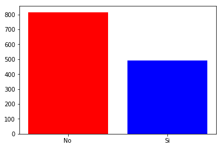

```python
import matplotlib.pyplot as plt
#Variable Survived
g_sobrevivieron = pd.crosstab(index=datos["Survived"],columns="count")
print(g_sobrevivieron)
alto = [g_sobrevivieron['count'][0], g_sobrevivieron['count'][1]]
barras = ('No ', 'Si')
y_pos = np.arange(len(barras))
plt.bar(y_pos, alto, color=['red','blue'])
plt.xticks(y_pos, barras)
```

```
col_0    count
Pclass
primera    321
segunda    277
tercera    709
```

```
 <a list of 3 Text xticklabel objects>)
```

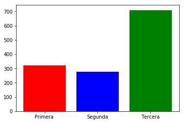

```python
#Variable Pclass
g_clase = pd.crosstab(index=datos["Pclass"],columns="count")
print(g_clase)
graf = [g_clase['count'][0], g_clase['count'][1],g_clase['count'][2]]
barras = ('Primera ', 'Segunda','Tercera')
y_pos = np.arange(len(barras))
plt.bar(y_pos, graf, color=['red','blue','green'])
plt.xticks(y_pos, barras)
```

```
col_0   count
Sex
female    464
male      843
```

```
 <a list of 2 Text xticklabel objects>)
```

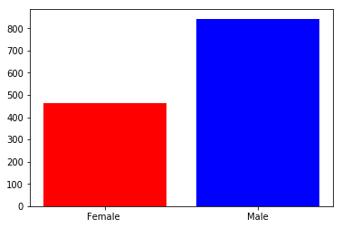

```python
#Variable Sexo
g_sexo = pd.crosstab(index=datos["Sex"],columns="count")
print(g_sexo)
alto = [g_sexo['count'][0], g_sexo['count'][1]]
barras = ('Female ', 'Male')
y_pos = np.arange(len(barras))
plt.bar(y_pos, alto, color=['red','blue'])
plt.xticks(y_pos, barras)
```

```
col_0     count
Embarked
C           270
Q           123
S           914
```

```
 <a list of 3 Text xticklabel objects>)
```

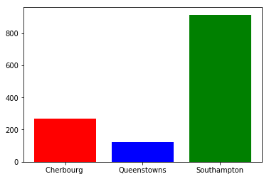

```python
#Variable Embarked
g_embarked = pd.crosstab(index=datos["Embarked"],columns="count")
print(g_embarked)
graf = [g_embarked['count'][0], g_embarked['count'][1],g_embarked['count'][2]]
barras = ('Cherbourg ', 'Queenstowns','Southampton')
y_pos = np.arange(len(barras))
plt.bar(y_pos, graf, color=['red','blue','green'])
plt.xticks(y_pos, barras)
```

e. Realice graficos tipo boxplot para encontrar los datos atipicos en esta tabla de datos.

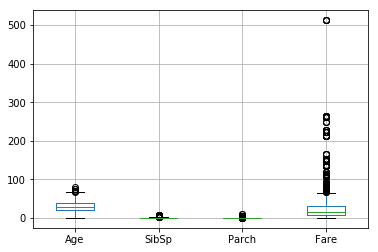

```python
boxplots = datos.boxplot(return_type='axes')
```

f. Realice histogramas, graficos de la funcion de densidad y test de normalidad para al menos dos variables de esta tabla de datos.

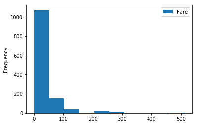

```python
#Histogramas
hist1 = datos[datos.columns[8:9]].plot(kind='hist')
```

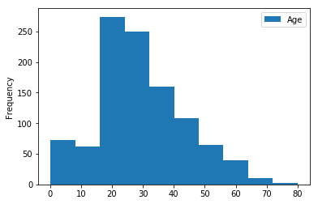

```python
hist2 = datos[datos.columns[4:5]].plot(kind='hist')
```

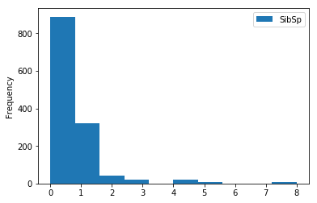

```python
hist3 = datos[datos.columns[5:6]].plot(kind='hist')
```

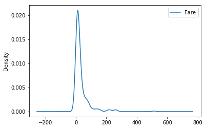

```python
#Densidad
densidad1 = datos[datos.columns[8:9]].plot(kind='density')
```

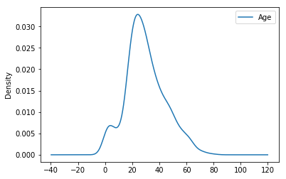

```python
densidad2 = datos[datos.columns[4:5]].plot(kind='density')
```

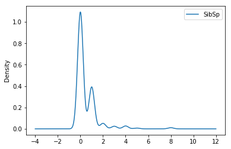

```python
densidad3 = datos[datos.columns[5:6]].plot(kind='density')
```

```
(nan, 1.0)
1.0
Si sigue la curva Normal (No se rechaza H0)
```

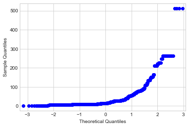

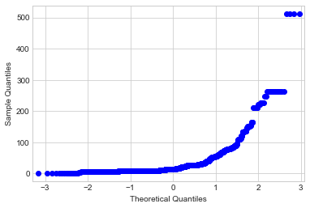

```python
#Test de normalidad
import scipy.stats
dat1 = datos['Fare']
shapiro_resultados = scipy.stats.shapiro(dat1)
print(shapiro_resultados)
p_value = shapiro_resultados[1]
print(p_value)

alpha = 0.05
if p_value > alpha:
    print('Si sigue la curva Normal (No se rechaza H0)')
else:
    print('No sigue la curva Normal (Se rechaza H0)')
from statsmodels.graphics.gofplots import qqplot
qqplot(dat1, line='s')
```

```
(0.5114514827728271, 0.0)
0.0
No sigue la curva Normal (Se rechaza H0)
```

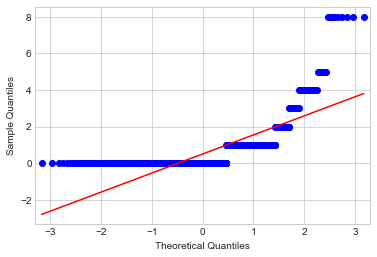

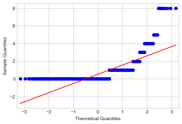

```python
#Test de normalidad SibSp
import scipy.stats
dat = datos['SibSp']
shapiro_resultados = scipy.stats.shapiro(dat)
print(shapiro_resultados)
p_value = shapiro_resultados[1]
print(p_value)

alpha = 0.05
if p_value > alpha:
    print('Si sigue la curva Normal (No se rechaza H0)')
else:
    print('No sigue la curva Normal (Se rechaza H0)')
from statsmodels.graphics.gofplots import qqplot
qqplot(dat, line='s')
```

g. Realice al menos dos scatter plot individuales y un grafico de todas las variables 2 a 2 usando el paquete Seaborn.

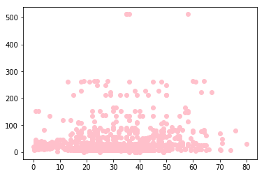

```python
#Scatter Plot
x = datos[datos.columns[4:5]]
y = datos[datos.columns[8:9]]
plt.plot(x, y, 'o', color='pink')
```

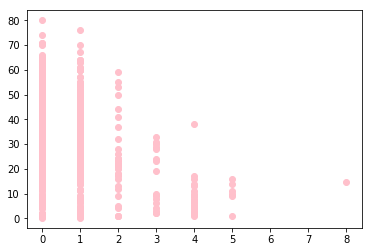

```python
x = datos[datos.columns[5:6]]
y = datos[datos.columns[4:5]]
plt.plot(x, y, 'o', color='pink')
```

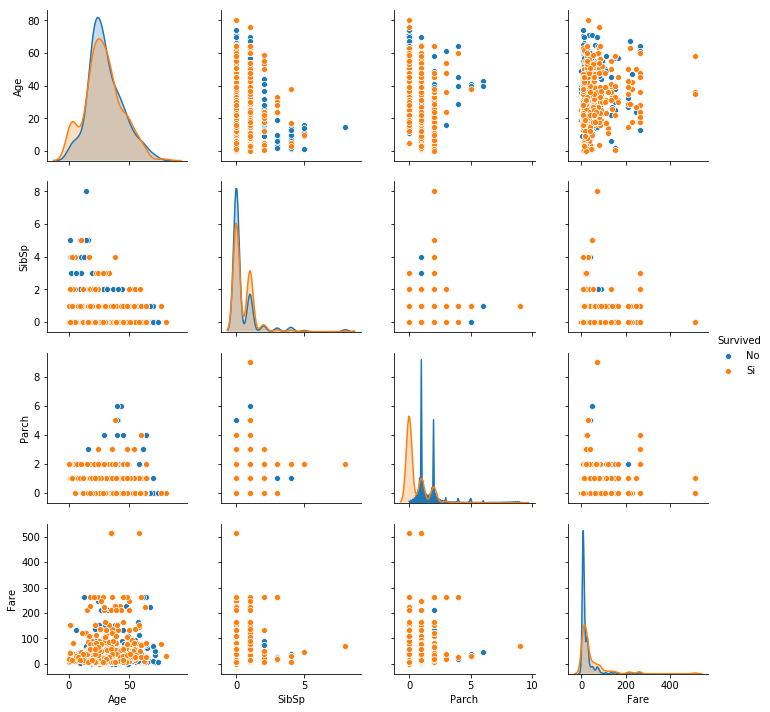

```python
#Variables 2 a 2
import seaborn as sns
import matplotlib.pyplot as plt
sns.pairplot(datos, hue='Survived', height=2.5)
```

h. Calcule y grafique la matriz de correlaciones.

```python
corr = datos.corr()
print(corr)
```

```
            Age     SibSp     Parch      Fare
Age    1.000000 -0.242910 -0.149992  0.177206
SibSp -0.242910  1.000000  0.373383  0.161030
Parch -0.149992  0.373383  1.000000  0.222327
Fare   0.177206  0.161030  0.222327  1.000000
```

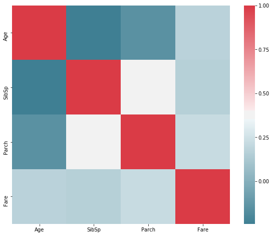

```python
f, ax = plt.subplots(figsize=(10, 8))
sns.heatmap(corr, mask=np.zeros_like(corr, dtype=np.bool), cmap=sns.diverging_palette(220, 10, as_cmap=True),square=True, ax=ax)
```

# Ejercicio #2:

a. Cargue la tabla de datos SAheart.csv

```python
import os
import pandas as pd
os.chdir("C:/Users/Estefania/Documents/UNIVERSIDAD/I Ciclo 2019/Mineria de Datos/Archivos")
datos1 = pd.read_csv('SAheart.csv',delimiter=';',decimal=".",index_col=0)
```

b. Recodifique las variables cualitativas que estan codificadas con numeros e ignore variables que no se deben usar, es decir, con valor unico.

R/. No hay variables cualitativas codificadas con numeros.

c. Calcule todas las estadsticas basicas en esta tabla de datos, incluya los analisis vistos en clase para variables numericas.

```python
import numpy as np
print(datos1.mean(numeric_only=True))
```

```
tobacco       3.635649
ldl           4.740325
adiposity    25.406732
typea        53.103896
obesity      26.044113
alcohol      17.044394
age          42.816017
dtype: float64
```

```python
print(datos1.median(numeric_only=True))
```

```
tobacco       2.000
ldl           4.340
adiposity    26.115
typea        53.000
obesity      25.805
alcohol       7.510
age          45.000
dtype: float64
```

```python
print(datos1.std(numeric_only=True))
```

```
tobacco       4.593024
ldl           2.070909
adiposity     7.780699
typea         9.817534
obesity       4.213680
alcohol      24.481059
age          14.608956
dtype: float64
```

```python
print(datos1.max(numeric_only=True))
```

```
tobacco       31.20
ldl           15.33
adiposity     42.49
typea         78.00
obesity       46.58
alcohol      147.19
age           64.00
dtype: float64
```

```python
print(datos1.min(numeric_only=True))
```

```
tobacco       0.00
ldl           0.98
adiposity     6.74
typea        13.00
obesity      14.70
alcohol       0.00
age          15.00
dtype: float64
```

```python
print(datos1.quantile(np.array([0,.25,.50,.75,1])))
```

```
      tobacco      ldl  adiposity  typea  obesity   alcohol   age
0.00   0.0000   0.9800     6.7400   13.0  14.7000    0.0000  15.0
0.25   0.0525   3.2825    19.7750   47.0  22.9850    0.5100  31.0
0.50   2.0000   4.3400    26.1150   53.0  25.8050    7.5100  45.0
0.75   5.5000   5.7900    31.2275   60.0  28.4975   23.8925  55.0
1.00  31.2000  15.3300    42.4900   78.0  46.5800  147.1900  64.0
```

d. Realice graficos de barras que ayuden a determinar la distribucion de las variables categoricas.

```
col_0    count
famhist
Absent     270
Present    192
```

```
 <a list of 2 Text xticklabel objects>)
```

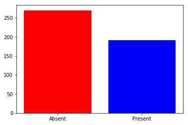

```python
#Variable famhist
g_fam = pd.crosstab(index=datos1["famhist"],columns="count")
print(g_fam)
alto = [g_fam['count'][0], g_fam['count'][1]]
barras = ('Absent', 'Present')
y_pos = np.arange(len(barras))
plt.bar(y_pos, alto, color=['red','blue'])
plt.xticks(y_pos, barras)
```

```
col_0  count
chd
No       302
Si       160
```

```
 <a list of 2 Text xticklabel objects>)
```

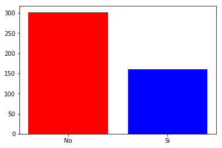

```python
#Variable chd
g_chd = pd.crosstab(index=datos1["chd"],columns="count")
print(g_chd)
alto = [g_chd['count'][0], g_chd['count'][1]]
barras = ('No', 'Si')
y_pos = np.arange(len(barras))
plt.bar(y_pos, alto, color=['red','blue'])
plt.xticks(y_pos, barras)
```

e. Realice graficos tipo boxplot para encontrar los datos atipicos en esta tabla de datos.

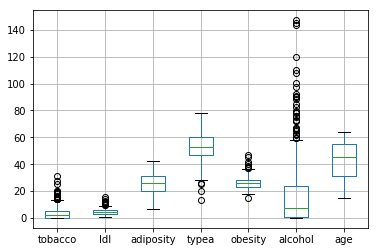

```python
boxplots = datos1.boxplot(return_type='axes')
```

f. Realice histogramas, graficos de la funcion de densidad y test de normalidad para al menos dos variables de esta tabla de datos.

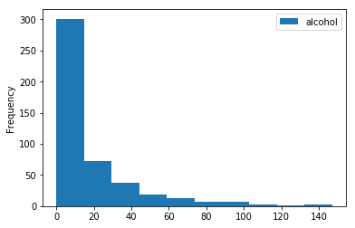

```python
#Histogramas
hist1 = datos1[datos1.columns[6:7]].plot(kind='hist')
```

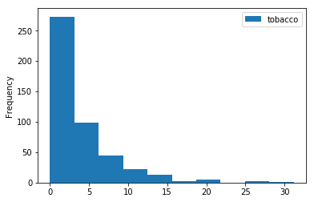

```python
hist2 = datos1[datos1.columns[0:1]].plot(kind='hist')
```

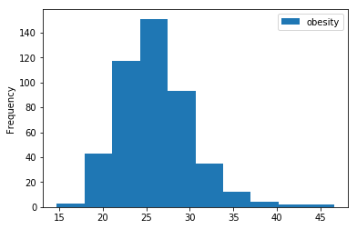

```python
hist3 = datos1[datos1.columns[5:6]].plot(kind='hist')
```

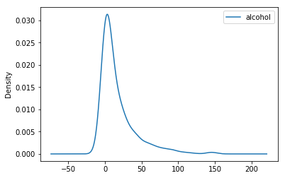

```python
#Densidad
densidad1 = datos1[datos1.columns[6:7]].plot(kind='density')
```

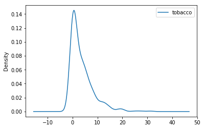

```python
densidad2 = datos1[datos1.columns[0:1]].plot(kind='density')
```

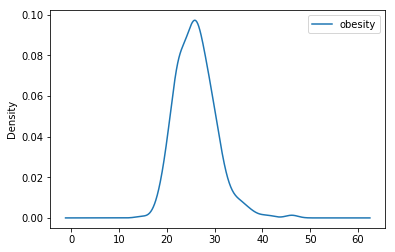

```python
densidad3 = datos1[datos1.columns[5:6]].plot(kind='density')
```

```
(0.7737232446670532, 9.267567496820392e-25)
9.267567496820392e-25
No sigue la curva Normal (Se rechaza H0)
```

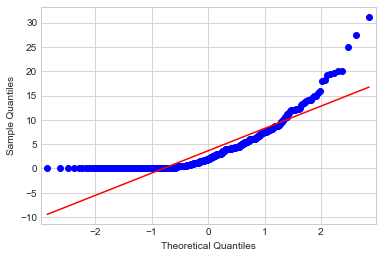

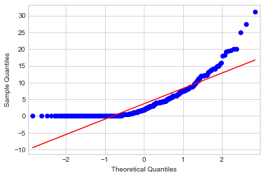

```python
#Test de normalidad Tobacco
import scipy.stats
dat = datos1['tobacco']
shapiro_resultados = scipy.stats.shapiro(dat)
print(shapiro_resultados)
p_value = shapiro_resultados[1]
print(p_value)

alpha = 0.05
if p_value > alpha:
    print('Si sigue la curva Normal (No se rechaza H0)')
else:
    print('No sigue la curva Normal (Se rechaza H0)')
from statsmodels.graphics.gofplots import qqplot
qqplot(dat, line='s')
```

```
(0.96074378490448, 9.225323838180088e-10)
9.225323838180088e-10
No sigue la curva Normal (Se rechaza H0)
```

[figure not shown]

[figure not shown]

```python
#Test de Normalidad Obesity
dat1 = datos1['obesity']
shapiro_resultados = scipy.stats.shapiro(dat1)
print(shapiro_resultados)
p_value = shapiro_resultados[1]
print(p_value)

alpha = 0.05
if p_value > alpha:
    print('Si sigue la curva Normal (No se rechaza H0)')
else:
    print('No sigue la curva Normal (Se rechaza H0)')
from statsmodels.graphics.gofplots import qqplot
qqplot(dat, line='s')
```

g. Realice al menos dos scatter plot individuales y un grafico de todas las variables 2 a 2 usando el paquete Seaborn.

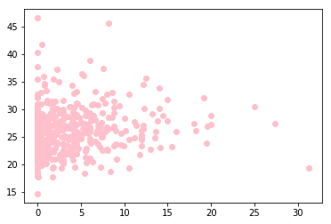

```python
x = datos1[datos1.columns[0:1]]
y = datos1[datos1.columns[5:6]]
plt.plot(x, y, 'o', color='pink')
```

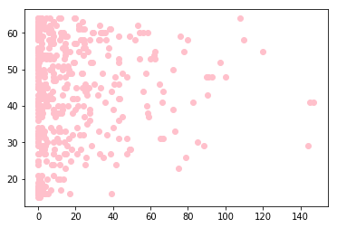

```python
x = datos1[datos1.columns[6:7]]
y = datos1[datos1.columns[7:8]]
plt.plot(x, y, 'o', color='pink')
```

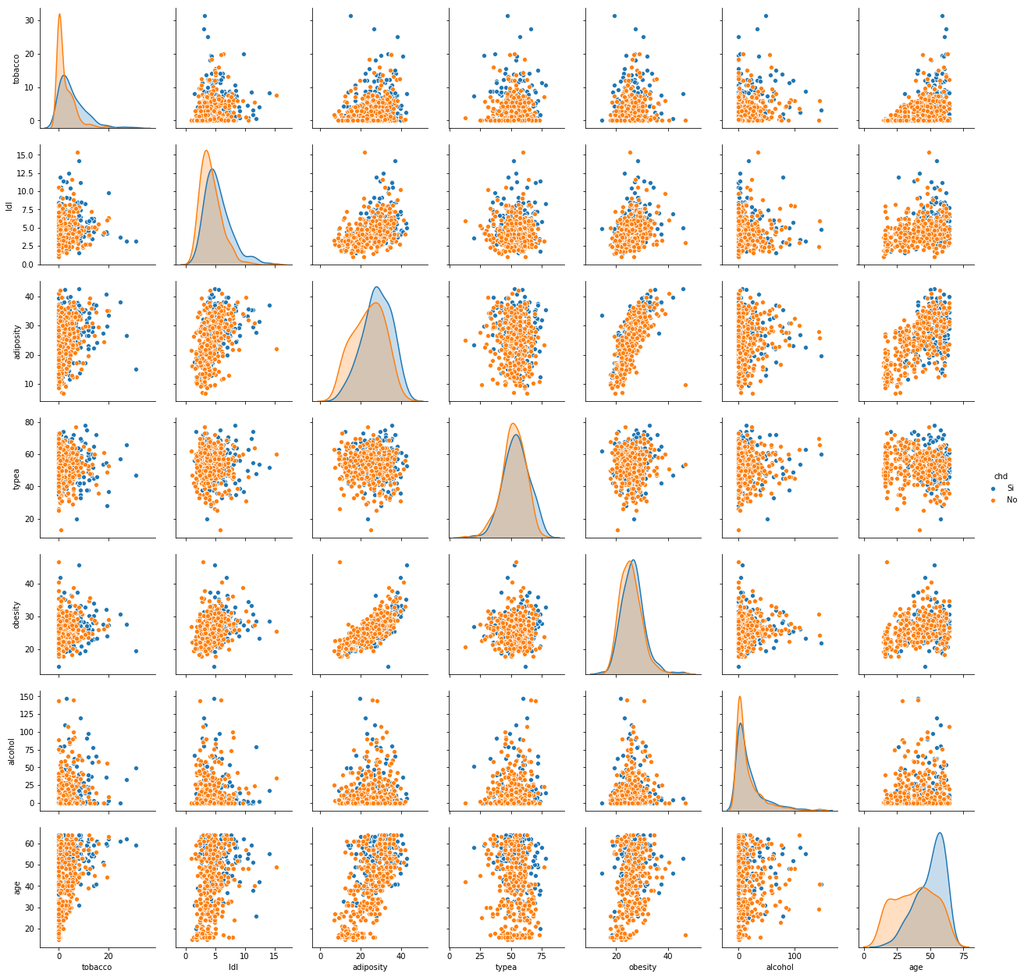

```python
#Variables 2 a 2
import seaborn as sns
import matplotlib.pyplot as plt
sns.pairplot(datos1, hue='chd', height=2.5)
```

h. Calcule y grafique la matriz de correlaciones.

```python
corr = datos1.corr()
print(corr)
```

```
            tobacco       ldl  adiposity     typea   obesity   alcohol  \
tobacco    1.000000  0.158905   0.286640 -0.014608  0.124529  0.200813
ldl        0.158905  1.000000   0.440432  0.044048  0.330506 -0.033403
adiposity  0.286640  0.440432   1.000000 -0.043144  0.716556  0.100330
typea     -0.014608  0.044048  -0.043144  1.000000  0.074006  0.039498
obesity    0.124529  0.330506   0.716556  0.074006  1.000000  0.051620
alcohol    0.200813 -0.033403   0.100330  0.039498  0.051620  1.000000
age        0.450330  0.311799   0.625954 -0.102606  0.291777  0.101125

                age
tobacco    0.450330
ldl        0.311799
adiposity  0.625954
typea     -0.102606
obesity    0.291777
alcohol    0.101125
age        1.000000
```

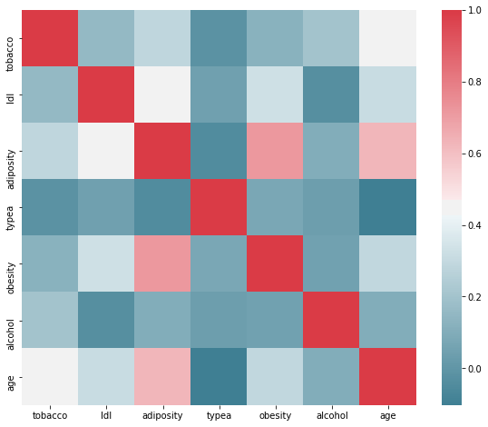

```python
f, ax = plt.subplots(figsize=(10, 8))
sns.heatmap(corr, mask=np.zeros_like(corr, dtype=np.bool), cmap=sns.diverging_palette(220, 10, as_cmap=True),square=True, ax=ax)
```

# Ejercicio #3:

```python
import os
import pandas as pd
import matplotlib.pyplot as plt
from prince import PCA
class ACP:
    def __init__(self, datos, n_componentes = 5):
        self.__datos = datos
        self.__modelo = PCA(n_components = n_componentes).fit(self.__datos)
        self.__correlacion_var = self.__modelo.column_correlations(datos)
        self.__coordenadas_ind = self.__modelo.row_coordinates(datos)
        self.__contribucion_ind = self.__modelo.row_contributions(datos)
        self.__cos2_ind = self.__modelo.row_cosine_similarities(datos)
        self.__var_explicada = [x * 100 for x in self.__modelo.explained_inertia_]
    @property
    def datos(self):
        return self.__datos
    @datos.setter
    def datos(self, datos):
        self.__datos = datos
    @property
    def modelo(self):
        return self.__modelo
    @property
    def correlacion_var(self):
        return self.__correlacion_var
    @property
    def coordenadas_ind(self):
        return self.__coordenadas_ind
    @property
    def contribucion_ind(self):
        return self.__contribucion_ind
    @property
    def cos2_ind(self):
        return self.__cos2_ind
    @property
    def var_explicada(self):
        return self.__var_explicada
        self.__var_explicada = var_explicada
    def plot_plano_principal(self, ejes = [0, 1], ind_labels = True, titulo = 'Plano Principal'):
        x = self.coordenadas_ind[ejes[0]].values
        y = self.coordenadas_ind[ejes[1]].values
        plt.style.use('seaborn-whitegrid')
        plt.scatter(x, y, color = 'gray')
        plt.title(titulo)
        plt.axhline(y = 0, color = 'dimgrey', linestyle = '--')
        plt.axvline(x = 0, color = 'dimgrey', linestyle = '--')
        inercia_x = round(self.var_explicada[ejes[0]], 2)
        inercia_y = round(self.var_explicada[ejes[1]], 2)
        plt.xlabel('Componente ' + str(ejes[0]) + ' (' + str(inercia_x) + '%)')
        plt.ylabel('Componente ' + str(ejes[1]) + ' (' + str(inercia_y) + '%)')
        if ind_labels:
            for i, txt in enumerate(self.coordenadas_ind.index):
                plt.annotate(txt, (x[i], y[i]))
    def plot_circulo(self, ejes = [0, 1], var_labels = True, titulo = 'Círculo de Correlación'):
        cor = self.correlacion_var.iloc[:, ejes].values
        plt.style.use('seaborn-whitegrid')
        c = plt.Circle((0, 0), radius = 1, color = 'steelblue', fill = False)
        plt.gca().add_patch(c)
        plt.axis('scaled')
        plt.title(titulo)
        plt.axhline(y = 0, color = 'dimgrey', linestyle = '--')
        plt.axvline(x = 0, color = 'dimgrey', linestyle = '--')
        inercia_x = round(self.var_explicada[ejes[0]], 2)
        inercia_y = round(self.var_explicada[ejes[1]], 2)
        plt.xlabel('Componente ' + str(ejes[0]) + ' (' + str(inercia_x) + '%)')
        plt.ylabel('Componente ' + str(ejes[1]) + ' (' + str(inercia_y) + '%)')
        for i in range(cor.shape[0]):
            plt.arrow(0, 0, cor[i, 0] * 0.95, cor[i, 1] * 0.95, color = 'steelblue',
                      alpha = 0.5, head_width = 0.05, head_length = 0.05)
            if var_labels:
                plt.text(cor[i, 0] * 1.05, cor[i, 1] * 1.05, self.correlacion_var.index[i],
                         color = 'steelblue', ha = 'center', va = 'center')
    def plot_sobreposicion(self, ejes = [0, 1], ind_labels = True,
                      var_labels = True, titulo = 'Sobreposición Plano-Círculo'):
        x = self.coordenadas_ind[ejes[0]].values
        y = self.coordenadas_ind[ejes[1]].values
        cor = self.correlacion_var.iloc[:, ejes]
        scale = min((max(x) - min(x)/(max(cor[ejes[0]]) - min(cor[ejes[0]]))),
                    (max(y) - min(y)/(max(cor[ejes[1]]) - min(cor[ejes[1]])))) * 0.7
        cor = self.correlacion_var.iloc[:, ejes].values
        plt.style.use('seaborn-whitegrid')
        plt.axhline(y = 0, color = 'dimgrey', linestyle = '--')
        plt.axvline(x = 0, color = 'dimgrey', linestyle = '--')
        inercia_x = round(self.var_explicada[ejes[0]], 2)
        inercia_y = round(self.var_explicada[ejes[1]], 2)
        plt.xlabel('Componente ' + str(ejes[0]) + ' (' + str(inercia_x) + '%)')
        plt.ylabel('Componente ' + str(ejes[1]) + ' (' + str(inercia_y) + '%)')
        plt.scatter(x, y, color = 'gray')
        if ind_labels:
            for i, txt in enumerate(self.coordenadas_ind.index):
                plt.annotate(txt, (x[i], y[i]))
        for i in range(cor.shape[0]):
            plt.arrow(0, 0, cor[i, 0] * scale, cor[i, 1] * scale, color = 'steelblue',
                      alpha = 0.5, head_width = 0.05, head_length = 0.05)
            if var_labels:
                plt.text(cor[i, 0] * scale * 1.15, cor[i, 1] * scale * 1.15,
                         self.correlacion_var.index[i],
                         color = 'steelblue', ha = 'center', va = 'center')
```

a. Efectue un ACP y de una interpretacion siguiendo los siguientes pasos:

a.1) En el plano principal encuentre los clusteres o segmentos.

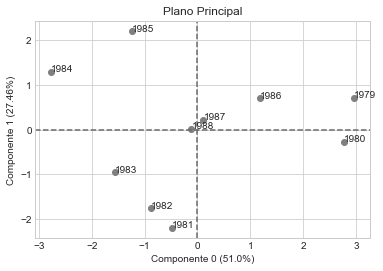

```python
os.chdir("C:/Users/Estefania/Documents/UNIVERSIDAD/I Ciclo 2019/Mineria de Datos/Archivos")
datos = pd.read_csv('ImportacionesMexico.csv',delimiter=';',decimal=",",index_col=0)

tabla = pd.DataFrame(data=datos)
acp = ACP(tabla)
acp.plot_plano_principal()
```

Primer cluster: 1984 y 1985.

Segundo cluster: 1981,1982 y 1983.

Tercer cluster: 1979, 1980 y 1986.

Cuarto cluester: 1987 y 1988.

a.2) En el circulo de correlacion determine la correlacion entre las variables e interpretelas.

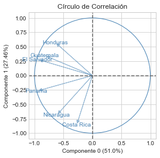

```python
acp.plot_circulo()
```

Honduras, Guatemala y El Salvador al estar tan cerca son fuertes y están positivamente correlacionadas.

No existe ninguna correlación entre Honduras y Nicaragua, al igual que entre Guatemala y Costa Rica.

Panama está correlacionado positivamente con El Salvador y Nicaragua.

a.3) Explique la formacion de los clusteres basado en la sobre-posicion del circulo y el plano, interprete (los annos 1987 y 1988 no se deben interpretar ya que estan muy mal representados en este plano, debido a que los cosenos cuadrados de estos a~no en las componentes 1 y 2 son muy bajos).

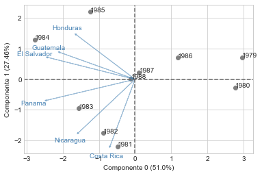

```python
acp.plot_sobreposicion()
```

En el primer cluster(1985 y 1984) se ve fuertemente impactado y de forma positiva por importaciones realizadas por Honduras, Guatemala y El Salvador.

En el segundo cluster (1981,1982 y 1983) se puede observar que las variables Costa Rica, Nicaragua y en cierta parte Panamá, tuvieron altas exportaciones en este periodo.

b) En el plano y circulo 1-3 (componentes 1 y 3) interprete los annos 1987 y 1988.

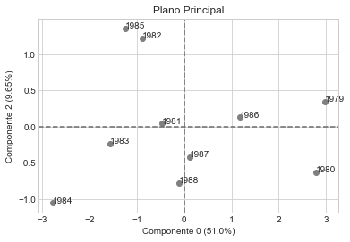

```python
a = [0,2]
acp.plot_plano_principal(a)
```

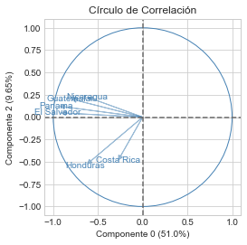

```python
acp.plot_circulo(a)
```

El cuarto cluster(1987 y 1988) se puede observar como se encuentra cercano a Costa Rica, por lo tanto son fuerte y positivamente correlacionadas. Se caracteriza por agrupar altas importaciones por este país.

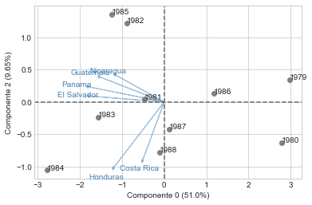

```python
acp.plot_sobreposicion(a)
```